#### **Optimal Solar Subsidies** with [Mark Colas](https://sites.google.com/site/markyaucolas/home) *Submitted*

We study the spatial misallocation resulting from subsidies for residential solar panels in the US and quantify the associated environmental costs. We build a structural model of solar panel demand and electricity production across the country and estimate the model by combining 1) remotely sensed data on residential solar panels, 2) power-plant-level data on hourly production and emissions, and 3) a state-of-the-art air pollution model. The current subsidies lead to severe spatial misallocation. The optimal cost-neutral reform generates environmental benefits equal to those of a 6-11% increase in the productivity of residential solar panels nationally.

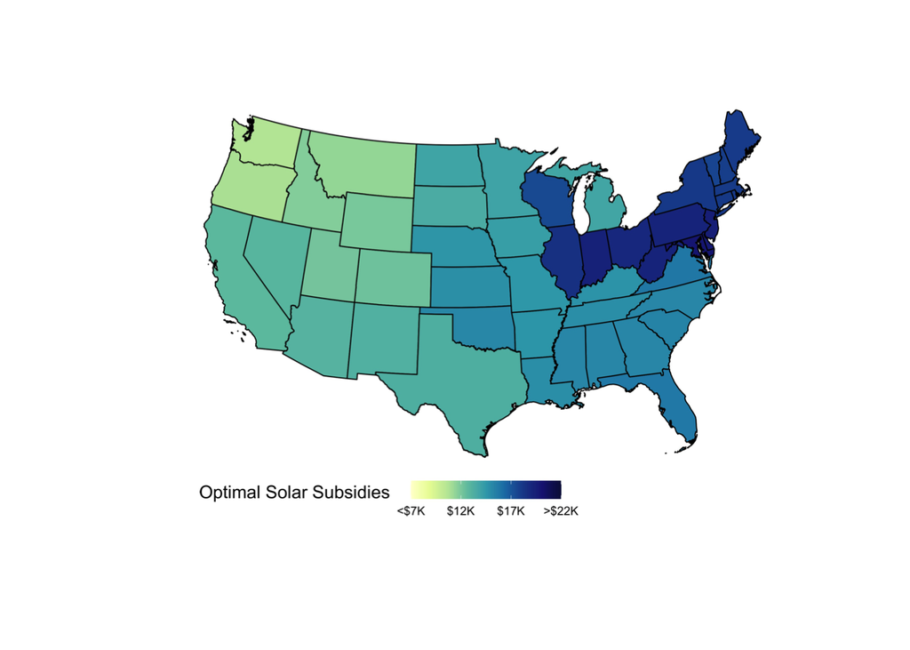

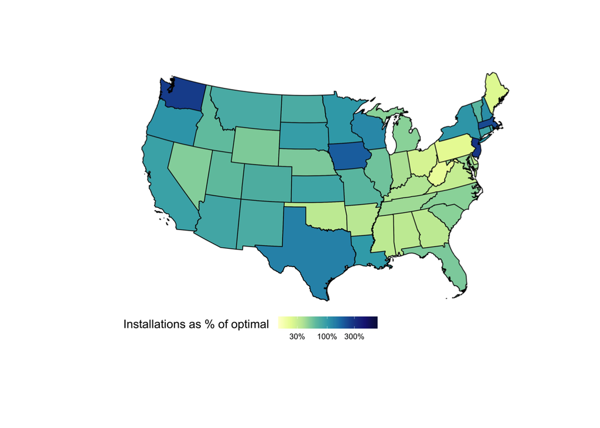

#### **Vertical Migration Externalities** with [Mark Colas](https://sites.google.com/site/markyaucolas/home)

*Revise and Resubmit at **Regional Science and Urban Economics***

State income taxes affect federal income tax revenue by shifting the spatial distribution of households between high- and low-productivity states, thereby changing household incomes and tax payments. We derive an expression for these fiscal externalities of state taxes in terms of estimable statistics. An empirical quantification using American Community Survey data reveals that the externalities range from large and negative in some states, to large and positive in others. In California, an increase in the state income tax rate and the resulting change in the distribution of households across states lead to a decrease in federal income tax revenue of 39 cents for every dollar of California tax revenue raised. The externality amounts to a 0.27% decrease in total federal income tax revenue for a 1 pp increase in California’s state tax rate. Our results raise the possibility that state taxes may be set too high in high-productivity states, and set too low in low-productivity states.